# A Case Study of Estimating Subnational U5MR using Cluster-level Methods

## Model comparisons

There are many options to change the model components. For example, we can use a different temporal component in the space-time interaction model. The default interaction model assumes the temporal component to follow the same model as the main temporal trend (so in the example above, random walk or order 2) and interact with a spatial ICAR process. Here we specify a different model where the space-time interaction is assumed to follow an AR(1) interacting with an ICAR process (via the `st.time.model` argument). We also add region-specific random slopes in time (via `pc.st.slope.u` and `pc.st.slope.alpha`; these two parameters specify the PC priors for the random slopes).

```r
fit.bb.ar1  <- smoothCluster(data = counts.all, Amat = DemoMap$Amat,
                    family = "betabinomial",
                    year_label = c(periods, "15-19"),
                    age.groups = c("0", "1-11", "12-23", "24-35", "36-47", "48-59"),
                    age.n = c(1,11,12,12,12,12),
                    age.rw.group = c(1,2,3,3,3,3),
                    time.model = "rw2", survey.effect = TRUE,
                    st.time.model = "ar1", type.st = 4,
                    pc.st.slope.u = 1, pc.st.slope.alpha = 0.1)
```

```
## ----------------------------------
## Cluster-level model
##   Main temporal model:        rw2
##   Spatial effect:             bym2
##   Interaction temporal model: ar1
##   Interaction type:           4
##   Interaction random slopes:  yes
##   Number of age groups: 6
##   Number of age-specific trends per stratum: 3
##   Stratification: no, strata variable not in the input
##   Survey effect: yes
## ----------------------------------
```

```r
summary(fit.bb.ar1)
```

```
## ----------------------------------
## Cluster-level model
##   Main temporal model:
##   Spatial effect:             bym2
##   Interaction temporal model: ar1
##   Interaction type:           4
##   Interaction random slopes:  yes
##   Number of age groups: 6
##   Number of age-specific trends per stratum: 3
##   Stratification: no, strata variable not in the input
##   Survey effect: yes
## ----------------------------------
## Fixed Effects
##          mean   sd 0.025quant 0.5quant 0.97quant mode kld
## age0     -2.9 0.11       -3.1     -2.9      -2.7 -2.9   0
## age1-11  -4.8 0.10       -5.0     -4.8      -4.6 -4.8   0
## age12-23 -5.8 0.12       -6.0     -5.8      -5.5 -5.8   0
## age24-35 -6.7 0.17       -7.0     -6.7      -6.4 -6.7   0
## age36-47 -7.1 0.20       -7.5     -7.1      -6.7 -7.0   0
## age48-59 -7.5 0.25       -8.0     -7.5      -7.0 -7.5   0
## ----------------------------------
## Random Effects
##            Name             Model
## 1   time.struct         RW2 model
## 2 time.unstruct         IID model
## 3 region.struct        BYM2 model
## 4    region.int Besags ICAR model
## 5   st.slope.id         IID model
## 6     survey.id         IID model
## ----------------------------------
## Model hyperparameters
##                                                     mean       sd 0.025quant
## overdispersion for the betabinomial observations   0.002    0.001      0.001
## Precision for time.struct                        179.445  328.369     12.059
## Precision for time.unstruct                      977.334 4621.273     14.789
## Precision for region.struct                      258.532  709.285      4.937
## Phi for region.struct                              0.353    0.255      0.022
## Precision for region.int                         631.786 2470.871     10.925
## Group PACF1 for region.int                         0.911    0.172      0.382
## Precision for st.slope.id                         33.179  103.493      0.923
##                                                  0.5quant 0.97quant   mode
## overdispersion for the betabinomial observations    0.002     0.005  0.002
## Precision for time.struct                          88.055   829.094 29.832
## Precision for time.unstruct                       226.131  5614.636 33.098
## Precision for region.struct                        88.401  1398.203 10.281
## Phi for region.struct                               0.298     0.880  0.057
## Precision for region.int                          168.704  3598.634 24.353
## Group PACF1 for region.int                          0.976     1.000  1.000
## Precision for st.slope.id                          10.804   180.630  2.177
##                                    [,1]
## Expectected  number of parameters  21.9
## Stdev of the number of parameters   2.1
## Number of equivalent replicates   772.9
##                                        [,1]
## log marginal-likelihood (integration) -3425
## log marginal-likelihood (Gaussian)    -3425
```

```r
est.bb.ar1 <- getSmoothed(fit.bb.ar1, nsim = 1000, CI = 0.95)
```

```
## Starting posterior sampling...
## Cleaning up results...
## No stratification in the model. Overall and stratified estimates are the same
```

Since we fit a non-stratified model, the `stratified` object and `overall` object in the returned list are the same. We can plot the estimates (or a subset of the estimates) using the S3 class plot function. For example, we plot the estimates for the first model with RW(2) interactions.

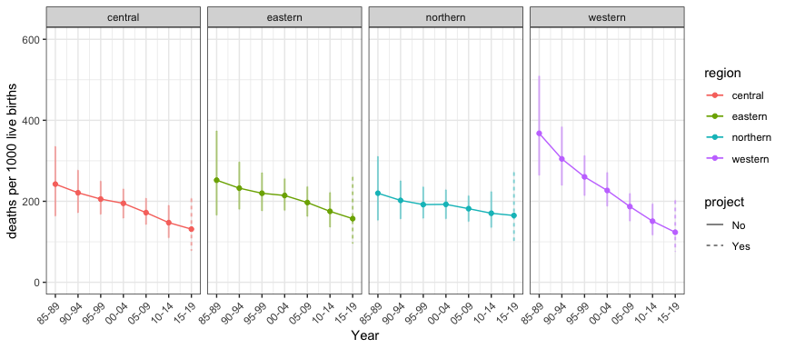

```r
library(ggplot2)
plot(est.bb$overall, per1000 = TRUE, plot.CI = TRUE) + facet_wrap(~region, ncol = 4) +
    ylim(0, 600) + theme(axis.text.x = element_text(angle = 45, hjust = 1))
```

In comparison, we plot the estimate from the AR(1) interaction model on the same scale. It can be seen that it induces stronger shrinkage for the region-specific slopes towards the shared trend.

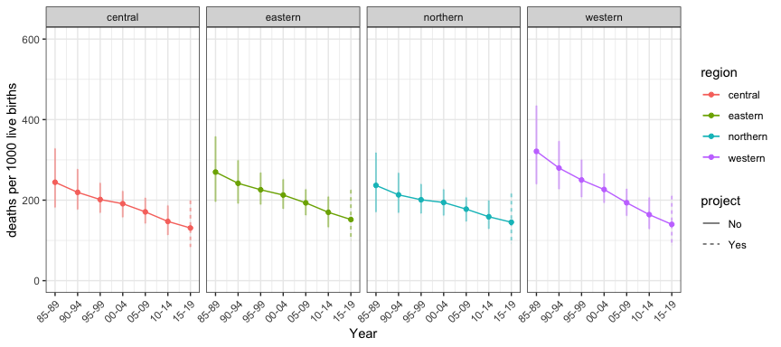

```r
plot(est.bb.ar1$overall, per1000 = TRUE, plot.CI = TRUE) + facet_wrap(~region, ncol = 4) +
    ylim(0, 600) + theme(axis.text.x = element_text(angle = 45, hjust = 1))
```

## More visualizations

We show the estimates on the map using the `mapPlot` function. We use the `DemoMap` from the package containing geographic data from the 1995 Uganda Admin 1 regions (but be aware the data are simulated and not correspond to Uganda child mortality).

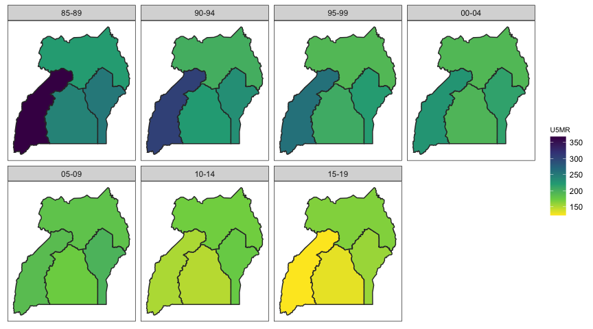

```r
data(DemoMap)
mapPlot(est.bb$overall,
        geo = DemoMap$geo, by.data = "region", by.geo = "REGNAME",
        is.long = TRUE, variables = "years", values = "median",
        ncol = 4, direction = -1, per1000 = TRUE, legend.label = "U5MR")
```

We can add hatching to indicate uncertainty of the estimates using `hatchPlot` with similar syntax.

[figure not shown]

```r
hatchPlot(est.bb$overall,
        geo = DemoMap$geo, by.data = "region", by.geo = "REGNAME",
        is.long = TRUE, variables = "years", values = "median",
        lower = "lower", upper = "upper", hatch = "red",
        ncol = 4, direction = -1, per1000 = TRUE, legend.label = "U5MR")
```

Next we show the posterior densities of the estimates, where each each panel correspond to one time period, and the regions are ordered by the posterior median of estimates in the last year (specified by the `order = -1` argument).

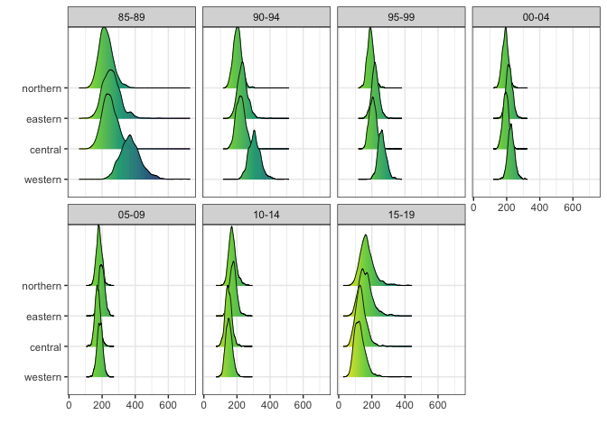

```r
ridgePlot(draws = est.bb, year_plot = c(periods, "15-19"),
                  ncol = 4, per1000 = TRUE, order = -1, direction = -1)
```

It can also be plotted for each region over time as well.

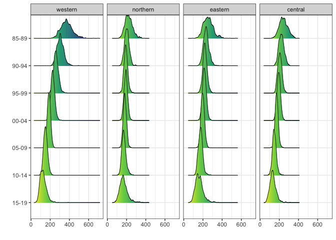

```r
ridgePlot(draws = est.bb, year_plot = c(periods, "15-19"),
                  ncol = 4, per1000 = TRUE, by.year = FALSE, direction = -1)
```